# 320 Final - Alec Luterman and Ansh Jain

## Introduction

YouTube is a social media platform that allows users to watch creators' videos. These videos can be about any topic, such as sports, entertainment, education, and music. As YouTube became more and more popular, creators started earning money based on how well their videos did. In fact, in today's society, some YouTubers (content creators) have made videos for their audience to enjoy their full-time jobs and become millionaires by doing so. Currently, YouTubers get paid on how many views they get per video; the more views a video has, the more money they get for that video. Here is a reference for how YouTubers earn money and how much they earn based off of videos: https://www.creditkarma.com/income/i/how-much-do-youtubers-make.

There are some problems with this, though. People could buy bots, or fake views, which could increase their view count artificially. A better way to track how well a video is doing is based on comments. If a video has a lot of comments, that means that a lot of real people viewed the video and wanted to discuss or interact with the creator. So, the more comments a YouTuber gets on their videos, the bigger community that YouTuber has. A bigger community can help YouTubers get money in other ways too. Content creators can get money through sponsorships or merchandise, and the more non-artificial people they have interacting with their video, the more likely they will get a sponsorship. Also, that means that it is probable that they will sell more merch, as artificial people cannot buy merch. Therefore, the amount of comments should be looked at for how well a YouTuber is doing and how much they should get paid.

This project uses a dataset that shows tens of thousands of YouTube videos and information about those videos, such as their likes, dislikes, comment count, the date and time that they were uploaded, and the description of the videos. This dataset contains the most popular YouTube videos, found from YouTube's most trending videos list. These parameters are used to analyze overall trends in the data to show how the amount of comments correlates with the other aspects relating to human interaction with the videos. We will use and explain the data science lifecycle to portray this analysis. This tutorial will show you how to collect the data, process the data, analyze and visualize the data, make inferences and predictions, including using machine learning, based on the data, and what all of that means.

```python
import numpy as np #used for mathematical operations
import pandas as pd #used for data processing
import matplotlib.pyplot as plt #used for plotting
import statsmodels.formula.api as smf #used for creating regression models
from scipy.stats import f #used for hypothesis testing
from scipy import stats #also used to create regression models
import json #used for getting data from json file
import os #used for unzipping dataset
import random #used for splitting data into test and train sets
```

**Step 0:** The dataset is retrieved from https://www.kaggle.com/datasets/datasnaek/youtube-new. After finding the dataset, we downloaded it and placed in the proper location so that the notebook file can access it.

## Data Extraction/Processing

**Step 1:** Now that we have the dataset in the project folder, this code unzips it. The problem is, though, that it tries to unzip every time and results in an infinite loop if the folder already exists, so the if statement ensures that the folder is not already unzipped before going thrugh the process of unzipping and storing it in the same directory.

```python
zip_path = 'Data.zip'
data_folder = 'Data'

# Check if the target directory already exists
if not os.path.exists(data_folder):
    os.makedirs(data_folder)
    !unzip {zip_path} -d {data_folder}
```

**Step 2:** This code extracts the csv file as a dataframe and displays the first five rows of the dataframe. This uses the pandas library to do that. Pandas has a in-built object called dataframes, which is a data structure that stores observations as tabular data. Storing the data this way makes it easier to manipulate and analyze.

```python
#Extracting the data from the csv file
df = pd.read_csv('Data/USvideos.csv')

df.head()
```

|  | video_id | trending_date | title | channel_title | category_id | publish_time | tags | views | likes | dislikes | comment_count | thumbnail_link | comments_disabled | ratings_disabled | video_error_or_removed | description |
| --- | --- | --- | --- | --- | --- | --- | --- | --- | --- | --- | --- | --- | --- | --- | --- | --- |
| 0 | 2kyS6SvSYSE | 17.14.11 | WE WANT TO TALK ABOUT OUR MARRIAGE | CaseyNeistat | 22 | 2017-11-13T17:13:01.000Z | SHANtell martin | 748374 | 57527 | 2966 | 15954 | https://i.ytimg.com/vi/2kyS6SvSYSE/default.jpg | False | False | False | SHANTELL'S CHANNEL - https://www.youtube.com/s... |
| 1 | 1ZAPwfrtAFY | 17.14.11 | The Trump Presidency: Last Week Tonight with J... | LastWeekTonight | 24 | 2017-11-13T07:30:00.000Z | last week tonight trump presidency\|"last week ... | 2418783 | 97185 | 6146 | 12703 | https://i.ytimg.com/vi/1ZAPwfrtAFY/default.jpg | False | False | False | One year after the presidential election, John... |
| 2 | 5qpjK5DgCt4 | 17.14.11 | Racist Superman \| Rudy Mancuso, King Bach & Le... | Rudy Mancuso | 23 | 2017-11-12T19:05:24.000Z | racist superman\|"rudy"\|"mancuso"\|"king"\|"bach"... | 3191434 | 146033 | 5339 | 8181 | https://i.ytimg.com/vi/5qpjK5DgCt4/default.jpg | False | False | False | WATCH MY PREVIOUS VIDEO ▶ \n\nSUBSCRIBE ► http... |
| 3 | puqaWrEC7tY | 17.14.11 | Nickelback Lyrics: Real or Fake? | Good Mythical Morning | 24 | 2017-11-13T11:00:04.000Z | rhett and link\|"gmm"\|"good mythical morning"\|"... | 343168 | 10172 | 666 | 2146 | https://i.ytimg.com/vi/puqaWrEC7tY/default.jpg | False | False | False | Today we find out if Link is a Nickelback amat... |
| 4 | d380meD0W0M | 17.14.11 | I Dare You: GOING BALD!? | nigahiga | 24 | 2017-11-12T18:01:41.000Z | ryan\|"higa"\|"higatv"\|"nigahiga"\|"i dare you"\|"... | 2095731 | 132235 | 1989 | 17518 | https://i.ytimg.com/vi/d380meD0W0M/default.jpg | False | False | False | I know it's been a while since we did this sho... |

**Step 3:** This step consists of data cleaning. In general, data cleaning is the removal and correction of invalid data. This is important to do so that the analysis is as accurate as possible. The code below removes all of the data that contains non-ascii text in the "descriptions" (video descriptions) column. Anything that is not considered normal text must be removed because some of our analysis performed later will be more accurate if those non-ascii characters are removed.

In order to actually filter out the invalid data, the first step we need to do is to create a boolean mask. A boolean mask is an array-like data structure that stores booleans for whether or not each observation/row in the dataframe meets a certain requirement. In this case, for each row we check if the column for the video description contains only ascii characters. We then negate our boolean mask in order to drop (delete) all invalid observations from our dataframe.

Note the deleted indices in the snippet of the dataframe below compared to our initial dataframe.

```python
# Remove each observation whose description contains non-ASCII text

bool_mask = df['description'].apply(lambda x: str(x).isascii())
non_ascii_mask = ~bool_mask

df = df.drop(df[non_ascii_mask].index, axis=0)

df.head()
```

|  | video_id | trending_date | title | channel_title | category_id | publish_time | tags | views | likes | dislikes | comment_count | thumbnail_link | comments_disabled | ratings_disabled | video_error_or_removed | description |
| --- | --- | --- | --- | --- | --- | --- | --- | --- | --- | --- | --- | --- | --- | --- | --- | --- |
| 0 | 2kyS6SvSYSE | 17.14.11 | WE WANT TO TALK ABOUT OUR MARRIAGE | CaseyNeistat | 22 | 2017-11-13T17:13:01.000Z | SHANtell martin | 748374 | 57527 | 2966 | 15954 | https://i.ytimg.com/vi/2kyS6SvSYSE/default.jpg | False | False | False | SHANTELL'S CHANNEL - https://www.youtube.com/s... |
| 1 | 1ZAPwfrtAFY | 17.14.11 | The Trump Presidency: Last Week Tonight with J... | LastWeekTonight | 24 | 2017-11-13T07:30:00.000Z | last week tonight trump presidency\|"last week ... | 2418783 | 97185 | 6146 | 12703 | https://i.ytimg.com/vi/1ZAPwfrtAFY/default.jpg | False | False | False | One year after the presidential election, John... |
| 4 | d380meD0W0M | 17.14.11 | I Dare You: GOING BALD!? | nigahiga | 24 | 2017-11-12T18:01:41.000Z | ryan\|"higa"\|"higatv"\|"nigahiga"\|"i dare you"\|"... | 2095731 | 132235 | 1989 | 17518 | https://i.ytimg.com/vi/d380meD0W0M/default.jpg | False | False | False | I know it's been a while since we did this sho... |
| 6 | 39idVpFF7NQ | 17.14.11 | Roy Moore & Jeff Sessions Cold Open - SNL | Saturday Night Live | 24 | 2017-11-12T05:37:17.000Z | SNL\|"Saturday Night Live"\|"SNL Season 43"\|"Epi... | 2103417 | 15993 | 2445 | 1970 | https://i.ytimg.com/vi/39idVpFF7NQ/default.jpg | False | False | False | Embattled Alabama Senate candidate Roy Moore (... |
| 8 | jr9QtXwC9vc | 17.14.11 | The Greatest Showman \| Official Trailer 2 [HD]... | 20th Century Fox | 1 | 2017-11-13T14:00:23.000Z | Trailer\|"Hugh Jackman"\|"Michelle Williams"\|"Za... | 826059 | 3543 | 119 | 340 | https://i.ytimg.com/vi/jr9QtXwC9vc/default.jpg | False | False | False | Inspired by the imagination of P.T. Barnum, Th... |

**Step 4:** This step involves more data cleaning. Now, we are fixing the dates and times and then converting them from strings to a datetime object. Datetime is an object that makes it easier to manipuate and analyze the date and times, which will be useful later on. To convert the strings to datetime, the string must be in a certain format. To convert both the year and the time, the format must be "%Y-%m-%d %H:%M:%S". For this dataset, we noticed there was a '000Z' at the end of all the terms. After doing some research, we realized this corresponds to the timezone. To verify that all objects were in the same time zone we used a boolean mask and saw every video in our dataframe had the exact same term so we can just remove it. To remove it, we just used the apply function and went through every row. In each row, we went to the "publish_time" column, or the column that is currently storing the date and time as a string, and replaced the ".000Z" with an empty string. Now that the timezone is removed, we are ready to convert to datetime. We took the whole "publish_time" column and added a new column to the dataframe that used pandas' "to_datetime" function to convert the strings from the "publish_time" column into a datetime object. After we went through the whole "publish_time" column, that data was useless to us since we had the exact same data as datetime objects, so we dropped that column.

```python
# convert publish_time to datetime
string_mask = df['publish_time'].apply(lambda x: x.replace('.000Z', ""))

df['publish_time'] = string_mask

df['upload_datetime'] = pd.to_datetime(df['publish_time'])
df = df.drop('publish_time', axis=1)

df.head()
```

|  | video_id | trending_date | title | channel_title | category_id | tags | views | likes | dislikes | comment_count | thumbnail_link | comments_disabled | ratings_disabled | video_error_or_removed | description | upload_datetime |
| --- | --- | --- | --- | --- | --- | --- | --- | --- | --- | --- | --- | --- | --- | --- | --- | --- |
| 0 | 2kyS6SvSYSE | 17.14.11 | WE WANT TO TALK ABOUT OUR MARRIAGE | CaseyNeistat | 22 | SHANtell martin | 748374 | 57527 | 2966 | 15954 | https://i.ytimg.com/vi/2kyS6SvSYSE/default.jpg | False | False | False | SHANTELL'S CHANNEL - https://www.youtube.com/s... | 2017-11-13 17:13:01 |
| 1 | 1ZAPwfrtAFY | 17.14.11 | The Trump Presidency: Last Week Tonight with J... | LastWeekTonight | 24 | last week tonight trump presidency\|"last week ... | 2418783 | 97185 | 6146 | 12703 | https://i.ytimg.com/vi/1ZAPwfrtAFY/default.jpg | False | False | False | One year after the presidential election, John... | 2017-11-13 07:30:00 |
| 4 | d380meD0W0M | 17.14.11 | I Dare You: GOING BALD!? | nigahiga | 24 | ryan\|"higa"\|"higatv"\|"nigahiga"\|"i dare you"\|"... | 2095731 | 132235 | 1989 | 17518 | https://i.ytimg.com/vi/d380meD0W0M/default.jpg | False | False | False | I know it's been a while since we did this sho... | 2017-11-12 18:01:41 |
| 6 | 39idVpFF7NQ | 17.14.11 | Roy Moore & Jeff Sessions Cold Open - SNL | Saturday Night Live | 24 | SNL\|"Saturday Night Live"\|"SNL Season 43"\|"Epi... | 2103417 | 15993 | 2445 | 1970 | https://i.ytimg.com/vi/39idVpFF7NQ/default.jpg | False | False | False | Embattled Alabama Senate candidate Roy Moore (... | 2017-11-12 05:37:17 |
| 8 | jr9QtXwC9vc | 17.14.11 | The Greatest Showman \| Official Trailer 2 [HD]... | 20th Century Fox | 1 | Trailer\|"Hugh Jackman"\|"Michelle Williams"\|"Za... | 826059 | 3543 | 119 | 340 | https://i.ytimg.com/vi/jr9QtXwC9vc/default.jpg | False | False | False | Inspired by the imagination of P.T. Barnum, Th... | 2017-11-13 14:00:23 |

**Step 5:** This step also includes more data cleaning. Since a big part of analyzing this data is looking at the comments and number of comments, having videos where comments are disabled is not helpful to us. So, we applied another boolean mask, this time setting the true value to check if the comments were disabled using the "comments_disabled" column. Then, we used pandas' drop function to drop every row where the comments were disabled.

```python
# removing videos without comments
bool_mask = df['comments_disabled'].apply(lambda x: str(x) == 'True')
df = df.drop(df[bool_mask].index, axis=0)

df.head()
```

|  | video_id | trending_date | title | channel_title | category_id | tags | views | likes | dislikes | comment_count | thumbnail_link | comments_disabled | ratings_disabled | video_error_or_removed | description | upload_datetime |
| --- | --- | --- | --- | --- | --- | --- | --- | --- | --- | --- | --- | --- | --- | --- | --- | --- |
| 0 | 2kyS6SvSYSE | 17.14.11 | WE WANT TO TALK ABOUT OUR MARRIAGE | CaseyNeistat | 22 | SHANtell martin | 748374 | 57527 | 2966 | 15954 | https://i.ytimg.com/vi/2kyS6SvSYSE/default.jpg | False | False | False | SHANTELL'S CHANNEL - https://www.youtube.com/s... | 2017-11-13 17:13:01 |
| 1 | 1ZAPwfrtAFY | 17.14.11 | The Trump Presidency: Last Week Tonight with J... | LastWeekTonight | 24 | last week tonight trump presidency\|"last week ... | 2418783 | 97185 | 6146 | 12703 | https://i.ytimg.com/vi/1ZAPwfrtAFY/default.jpg | False | False | False | One year after the presidential election, John... | 2017-11-13 07:30:00 |
| 4 | d380meD0W0M | 17.14.11 | I Dare You: GOING BALD!? | nigahiga | 24 | ryan\|"higa"\|"higatv"\|"nigahiga"\|"i dare you"\|"... | 2095731 | 132235 | 1989 | 17518 | https://i.ytimg.com/vi/d380meD0W0M/default.jpg | False | False | False | I know it's been a while since we did this sho... | 2017-11-12 18:01:41 |
| 6 | 39idVpFF7NQ | 17.14.11 | Roy Moore & Jeff Sessions Cold Open - SNL | Saturday Night Live | 24 | SNL\|"Saturday Night Live"\|"SNL Season 43"\|"Epi... | 2103417 | 15993 | 2445 | 1970 | https://i.ytimg.com/vi/39idVpFF7NQ/default.jpg | False | False | False | Embattled Alabama Senate candidate Roy Moore (... | 2017-11-12 05:37:17 |
| 8 | jr9QtXwC9vc | 17.14.11 | The Greatest Showman \| Official Trailer 2 [HD]... | 20th Century Fox | 1 | Trailer\|"Hugh Jackman"\|"Michelle Williams"\|"Za... | 826059 | 3543 | 119 | 340 | https://i.ytimg.com/vi/jr9QtXwC9vc/default.jpg | False | False | False | Inspired by the imagination of P.T. Barnum, Th... | 2017-11-13 14:00:23 |

**Step 6:** This step involves a combination of data cleaning and data extraction. When looking at the snippet of the dataframe above, we can see that the category_id column simply stores an integer; this is not that useful to us since it is a categorical variable without a category name. However, we have the data to fill in this information as part of the dataset we downloaded. There is a JSON file, view more info on JSON files here: https://blog.hubspot.com/website/json-files, called US_category_id.json that contains all of the info required to replace the integers for category id with the actual category names.

To do this, we first need to load in the JSON file which we can simply do using json.load(file), which loads the json file as a python dictionary. We then use python list comprehension in order to extract the neccesary category information as a list of tuples of category id number to category name. We then define a function to make this replacement for a given row in our dataframe and use the pandas dataframe.apply method to make make this swap for every row.

```python
with open('Data/US_category_id.json', 'r') as file:
    data = json.load(file)
categories_list = [(item["id"], item["snippet"]["title"]) for item in data["items"]]

def str_cat_id(x):

    for y in categories_list:

        if str(x) == str(y[0]):

            return y[1]

    return np.nan


df['category_id'] = df['category_id'].apply(lambda x: str_cat_id(x))
df.head()
```

|  | video_id | trending_date | title | channel_title | category_id | tags | views | likes | dislikes | comment_count | thumbnail_link | comments_disabled | ratings_disabled | video_error_or_removed | description | upload_datetime |
| --- | --- | --- | --- | --- | --- | --- | --- | --- | --- | --- | --- | --- | --- | --- | --- | --- |
| 0 | 2kyS6SvSYSE | 17.14.11 | WE WANT TO TALK ABOUT OUR MARRIAGE | CaseyNeistat | People & Blogs | SHANtell martin | 748374 | 57527 | 2966 | 15954 | https://i.ytimg.com/vi/2kyS6SvSYSE/default.jpg | False | False | False | SHANTELL'S CHANNEL - https://www.youtube.com/s... | 2017-11-13 17:13:01 |
| 1 | 1ZAPwfrtAFY | 17.14.11 | The Trump Presidency: Last Week Tonight with J... | LastWeekTonight | Entertainment | last week tonight trump presidency\|"last week ... | 2418783 | 97185 | 6146 | 12703 | https://i.ytimg.com/vi/1ZAPwfrtAFY/default.jpg | False | False | False | One year after the presidential election, John... | 2017-11-13 07:30:00 |
| 4 | d380meD0W0M | 17.14.11 | I Dare You: GOING BALD!? | nigahiga | Entertainment | ryan\|"higa"\|"higatv"\|"nigahiga"\|"i dare you"\|"... | 2095731 | 132235 | 1989 | 17518 | https://i.ytimg.com/vi/d380meD0W0M/default.jpg | False | False | False | I know it's been a while since we did this sho... | 2017-11-12 18:01:41 |
| 6 | 39idVpFF7NQ | 17.14.11 | Roy Moore & Jeff Sessions Cold Open - SNL | Saturday Night Live | Entertainment | SNL\|"Saturday Night Live"\|"SNL Season 43"\|"Epi... | 2103417 | 15993 | 2445 | 1970 | https://i.ytimg.com/vi/39idVpFF7NQ/default.jpg | False | False | False | Embattled Alabama Senate candidate Roy Moore (... | 2017-11-12 05:37:17 |
| 8 | jr9QtXwC9vc | 17.14.11 | The Greatest Showman \| Official Trailer 2 [HD]... | 20th Century Fox | Film & Animation | Trailer\|"Hugh Jackman"\|"Michelle Williams"\|"Za... | 826059 | 3543 | 119 | 340 | https://i.ytimg.com/vi/jr9QtXwC9vc/default.jpg | False | False | False | Inspired by the imagination of P.T. Barnum, Th... | 2017-11-13 14:00:23 |

## Exploratory Analysis and Data Visualization

**Step 7:** Now that we have cleaned all the data that we are planning on using, we can start analyzing and visualizing that data. In this step, we are comparing the years to views for each category ID (explained above). We group each category_id using the pandas "groupby" function, explained here: https://pandas.pydata.org/pandas-docs/stable/reference/api/pandas.DataFrame.groupby.html. Then, we go through each group and plot each year (from our datetime column) as the x-axis and the change in views for that category over those years. The "plt.subplots" creates a subplot, meaning it creates the actual plot where the points will be graphed onto. The grp.plot() line is the one that actually plots the data onto the graph. "Grp" is each group and the parameters for the plot() are the plot, the type of plot, which is a line plot in this case, then the x axis, which is the date, the y axis, which is the views, and the label, which will be used for the legend. "Plt.title" is used to give a title to the plot. "Plt.xlabel" is the title of the x-axis of the plot. "Plt.ylabel" is the title of the y-label of the plot. "Plt.legend" displays the legend, which, in this case, shows the color for each category. "Plt.grid" shows a grid in the background.

A guide for the most common matplotlib functions are explained here: https://matplotlib.org/stable/gallery/subplots_axes_and_figures/subplots_demo.html

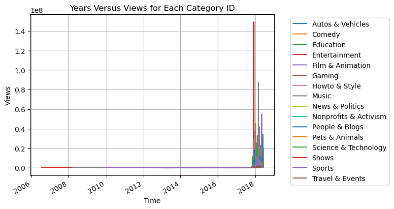

```python
fig, ax = plt.subplots()

for key, grp in df.groupby(['category_id']):

    ax = grp.plot(ax=ax, kind='line', x='upload_datetime', y='views', label=key)

plt.title('Years Versus Views for Each Category ID')
plt.xlabel('Time')
plt.ylabel('Views')
plt.legend(bbox_to_anchor=(1.05, 1), loc='upper left')
plt.grid(True)
```

**Explanation of Graph:** This graph is plotting the number of video views by date for the different possible categories. As you can see, this plot is not that useful in understanding the data. There does not seem to be any direct correlation between the number of views and the years for the categories; they are kind of all over the place. So, what if we look at a portion of the data?

**Step 8:** As mentioned above, the graph that shows all dates versus views for each category does not really tell us anything. We looked at it, though, and realized most of the clutter is in 2018. So, we thought that we should plot another graph that only shows views vs time for each category for 2018. The code is mostly the same, except we used a boolean mask that only keeps rows where the datetime is January 1st, 2018 or later.

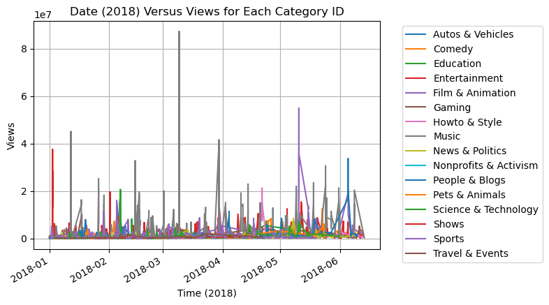

```python
fig, ax = plt.subplots()

start_date = pd.to_datetime(f'{2018}-01-01')
filtered_dates = df[df['upload_datetime'] >= start_date].copy()

for key, grp in filtered_dates.groupby(['category_id']):

    ax = grp.plot(ax=ax, kind='line', x='upload_datetime', y='views', label=key)

plt.title('Date (2018) Versus Views for Each Category ID')
plt.xlabel('Time (2018)')
plt.ylabel('Views')
plt.legend(bbox_to_anchor=(1.05, 1), loc='upper left')
plt.grid(True)
```

**Explanation/Examination of Plot:** Now that we were able to look more closely at the main cluster of data, it appears that there is no correlation between the number of views for any of the categories across time.

**Step 9:** This step includes more data visualization. It creates a bar graph that displays how many videos of each category are in the dataset. This is important to know because it is helpful to see what the most popular and least popular videos that content creators make are. The "value_counts()" function sums up the number of times each category is in the "category_id" column and stores all the results as a list. Then, that list is plotted as a bar graph. "Plt.figure" creates the size of the plot. In this case, it has width of 28 and length of 4. Then, "frequency.plot" plots the number of each category as the type of plot specified, which is a bar plot in this case.

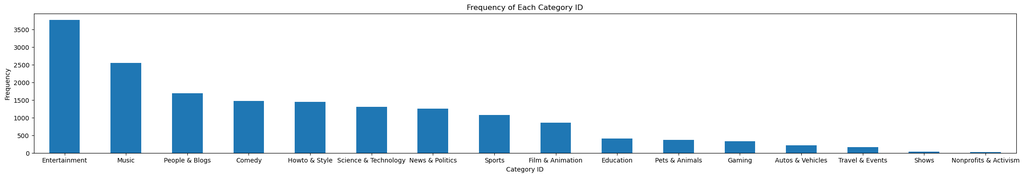

```python
frequency = df['category_id'].value_counts()

plt.figure(figsize=(28, 4))
frequency.plot(kind='bar')
plt.title('Frequency of Each Category ID')
plt.xticks(rotation=0)
plt.xlabel('Category ID')
plt.ylabel('Frequency')
```

**Explanation of Graph:** The graph above shows how many YouTube videos were in each possible category. The most frequent type of content was entertainment, while the least frequent type of content was nonprofits and activism. This means that the most popular videos, meaning the videos that users mostly watch, are entertainment videos, while the videos that are least popular focus on nonprofits and activism.

## Hypotheses Testing

**Step 10:** Since the main result that we want to examine is the comment count for each video, we want to find out what the relation is between views and comment. To do this, lets create a simple linear regression.

The first step in this process is to extract the variables from our dataframe that we want to examine which we do via column selection from our dataframe. In this case we select views (independent variable) and comment_count (dependent variable). We then want to set up a least squares problem, where (in general) we want to find m and b such that y^(x) = mx+b is the best possible predictor of y(x). Least squares defines this optimal predictor as the predictor function that minimizes the sum of squares of the residuals. A residual is the difference between the value that our model predicts for a given x and actual value. We can set this up as a linear system and try to find Θ such that XΘ = Y^ minimizes distance between Y^ and Y We can calculate Θ by solving Θ = (X^T *X)^-1* X^T * Y. To do this in Python, we can convert our extracted columns into two numpy arrays, one for our independent variables and one for our dependent variables. Since we want to fit our data to y^ = mx + b, we need to also account for our intercept term. We can do this by creating a column in our X numpy array that is all ones. We then use numpy's least squares function with X and Y to find our slope and intercept for our regression line.

To plot the regression line, we simply use plt's plot() function, inputting our x variables, and use our intercept and slope to calculate our predicted values. We can use plt's scatter function to plot the actual values.

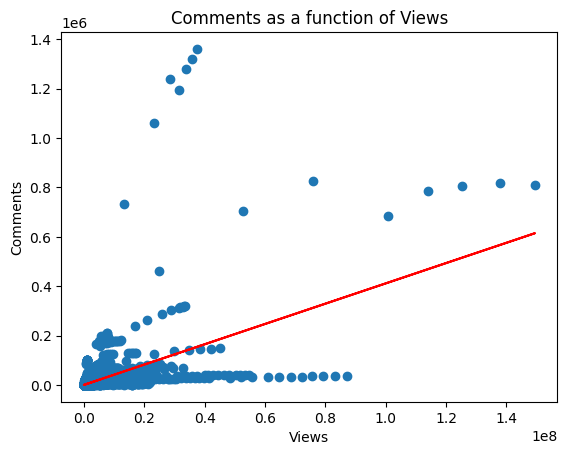

```python
df_lin_reg = df[['views', 'comment_count']]
np_lin_reg = df_lin_reg.values
X = np_lin_reg[:,0]
X_ones = np.vstack([X, np.ones(len(X))]).T
Y = np_lin_reg[:,1]

lst_sq, residual, _, _ = np.linalg.lstsq(X_ones, Y, rcond=None)
slope, intercept = lst_sq

fig, ax = plt.subplots(nrows=1, ncols=1)
ax.scatter(df['views'], df['comment_count'])
ax.plot(X, intercept + slope*X, 'r')
ax.set_title('Comments as a function of Views')
ax.set_xlabel('Views')
ax.set_ylabel('Comments')
plt.show()
```

**Explanation of Graph** This graph shows comments as a function of views, and the corresponding linear regression. Visually, there appears to be a positive linear correlation, however it does not appear to be a strong correlation.

**Step 11:** Lets verify our claims from above: we will perform hypothesis testing. To get statistics about our regression, we can use statsmodels's ordinary least squares function, where we define that we want comment_count as a function of views. We can then print a summary table which includes all of the data necessary for model analysis. From the table, the two most important pieces of information are the R-squared value and the F-Statistic. R-squared tells us the proportion of the variance in our dependent variable that is explained by our regression model (Analysis in next section). The F-statistic tests whether at least one of the regression coefficients is significantly different from zero, indicating whether the overall regression model provides a better fit to the data than a model with no predictors.

In addition, we need to calculate our critical value which we will compare to our F statistic. To do this, we need a siginificnce level (alpha = 0.05), and need to know the number of degrees of freedom and the degree of freedom residuals which can be seen from the OLS summary.

You can read more on stats model formulas here: https://www.statsmodels.org/dev/examples/notebooks/generated/formulas.html

```python
lin_reg = smf.ols(formula="comment_count ~ views ", data=df).fit()
print(lin_reg.summary())

alpha = 0.05
dfn = 1 #k (degrees of freedom)
dfd = 16983 #n - k -1

critical_val = f.ppf(1-alpha, dfn, dfd)
print("critical_val: ", critical_val)
```

```
                            OLS Regression Results
==============================================================================
Dep. Variable:          comment_count   R-squared:                       0.300
Model:                            OLS   Adj. R-squared:                  0.300
Method:                 Least Squares   F-statistic:                     7274.
Date:                Sat, 18 May 2024   Prob (F-statistic):               0.00
Time:                        16:36:46   Log-Likelihood:            -1.9742e+05
No. Observations:               16985   AIC:                         3.948e+05
Df Residuals:                   16983   BIC:                         3.949e+05
Df Model:                           1
Covariance Type:            nonrobust
==============================================================================
                 coef    std err          t      P>|t|      [0.025      0.975]
------------------------------------------------------------------------------
Intercept   -269.6828    222.116     -1.214      0.225    -705.054     165.689
views          0.0041   4.82e-05     85.289      0.000       0.004       0.004
==============================================================================
Omnibus:                    42210.356   Durbin-Watson:                   1.992
Prob(Omnibus):                  0.000   Jarque-Bera (JB):        847046947.301
Skew:                          26.845   Prob(JB):                         0.00
Kurtosis:                    1095.705   Cond. No.                     4.93e+06
==============================================================================

Notes:
[1] Standard Errors assume that the covariance matrix of the errors is correctly specified.
[2] The condition number is large, 4.93e+06. This might indicate that there are
strong multicollinearity or other numerical problems.
critical_val:  3.842006433905074
```

**Analysis of Regression:** If we have our null hypothesis H0 be there is no relationship between views and comments, then we would reject that hypothesis. The reason we reject this hypothesis is that since alpha = 0.05, based on our dataset we have a critical value of 3.842. From the OLS linear regression data, we have an F statistic of 7274. Since our critical value is less than our F statistic, we reject our null hypothesis. Thus there is a relationship between views and comments.

Since we have an R-squared value of 0.3, that means that 30% of the variance in our comment count is explained by our regression model.

**Step 12:** Even though our model was statistically significant, the accuracy of it was relatively low as seen by the R-squared value. What if we examine each video category seperately? To do this, we once again use the pandas groupby function to seperate based on category. We then iterate over each video category and create a regression line using scipy.stats.linregress for each category seperately.

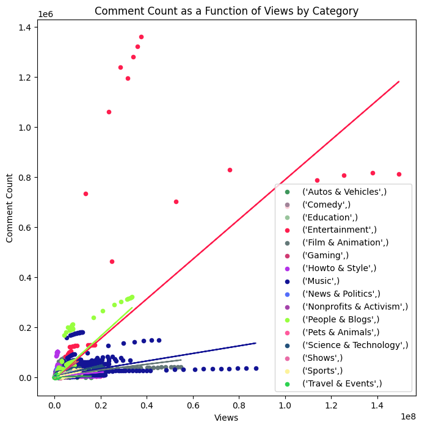

```python
df_by_cont = df.groupby(['category_id'])
groups = df_by_cont.groups

def generate_color():
    return "#{:02x}{:02x}{:02x}".format(random.randint(0, 255), random.randint(0, 255), random.randint(0, 255))

colors = [generate_color() for _ in range(20)]

fig, ax = plt.subplots(figsize=(8,8))
for idx, (key, values) in enumerate(df.groupby(['category_id'])):

    ax = values.plot(ax=ax, kind='scatter', x='views', y='comment_count', label=key, color=colors[idx])
    x = values['views']
    y = values['comment_count']
    res = stats.linregress(x,y)
    ax.plot(x, res.intercept + res.slope*x, colors[idx])

ax.set_title('Comment Count as a Function of Views by Category')
ax.set_xlabel('Views')
ax.set_ylabel('Comment Count')
```

**Explanation of Graph:** This graph plots the comment counts of videos as a function of views, seperated for each video category. We can see, that there is a positive correlation between video views and video comments for each category, and that there is a big difference between the slope of the regression line from category to category.

**Step 13:** Now that we seperate for video category, how accurate is our model? Before we do this, we need to introduce the idea of interactions, read more on interactions here: https://statisticsbyjim.com/regression/interaction-effects/. To put it simply, interactions allow us to handle the dependencies between our independent variables. We use smf.ols to account for an interaction and we do this by specifying categories*other_var as the independent variable in our stats model formula. Afterwards, the steps for analysis are the same as before.

```python
lin_reg2 = smf.ols(formula='comment_count ~ category_id*views', data=df).fit()
print(str(lin_reg2.summary()))

alpha = 0.05
dfn = 31 #k (degrees of freedom)
dfd = 16953 #n - k -1

critical_val = f.ppf(1-alpha, dfn, dfd)
print("critical_val: ", critical_val)
```

```
                            OLS Regression Results
==============================================================================
Dep. Variable:          comment_count   R-squared:                       0.481
Model:                            OLS   Adj. R-squared:                  0.480
Method:                 Least Squares   F-statistic:                     506.5
Date:                Sat, 18 May 2024   Prob (F-statistic):               0.00
Time:                        16:58:08   Log-Likelihood:            -1.9488e+05
No. Observations:               16985   AIC:                         3.898e+05
Df Residuals:                   16953   BIC:                         3.901e+05
Df Model:                          31
Covariance Type:            nonrobust
==============================================================================================================
                                                 coef    std err          t      P>|t|      [0.025      0.975]
--------------------------------------------------------------------------------------------------------------
Intercept                                   2129.1284   1716.377      1.240      0.215   -1235.149    5493.405
category_id[T.Comedy]                       1141.2892   1874.930      0.609      0.543   -2533.768    4816.347
category_id[T.Education]                   -2186.7757   2178.003     -1.004      0.315   -6455.888    2082.336
category_id[T.Entertainment]               -7179.9191   1761.814     -4.075      0.000   -1.06e+04   -3726.580
category_id[T.Film & Animation]             3284.6419   1930.980      1.701      0.089    -500.280    7069.563
category_id[T.Gaming]                      -3469.6430   2507.718     -1.384      0.167   -8385.032    1445.746
category_id[T.Howto & Style]                1869.9294   1844.735      1.014      0.311   -1745.942    5485.801
category_id[T.Music]                        2080.9915   1792.188      1.161      0.246   -1431.883    5593.867
category_id[T.News & Politics]              -166.8601   1874.301     -0.089      0.929   -3840.686    3506.965
category_id[T.Nonprofits & Activism]       -2183.1986   9427.885     -0.232      0.817   -2.07e+04    1.63e+04
category_id[T.People & Blogs]              -5623.6463   1828.849     -3.075      0.002   -9208.381   -2038.912
category_id[T.Pets & Animals]              -1612.9457   2268.796     -0.711      0.477   -6060.022    2834.131
category_id[T.Science & Technology]         -956.2073   1867.109     -0.512      0.609   -4615.934    2703.520
category_id[T.Shows]                        -902.7184   6621.051     -0.136      0.892   -1.39e+04    1.21e+04
category_id[T.Sports]                      -1959.2249   1913.329     -1.024      0.306   -5709.549    1791.099
category_id[T.Travel & Events]             -1764.8193   3179.319     -0.555      0.579   -7996.614    4466.976
views                                        6.45e-05      0.001      0.090      0.928      -0.001       0.001
category_id[T.Comedy]:views                    0.0024      0.001      2.946      0.003       0.001       0.004
category_id[T.Education]:views                 0.0037      0.001      2.704      0.007       0.001       0.006
category_id[T.Entertainment]:views             0.0079      0.001     10.908      0.000       0.006       0.009
category_id[T.Film & Animation]:views          0.0011      0.001      1.486      0.137      -0.000       0.003
category_id[T.Gaming]:views                    0.0062      0.001      6.190      0.000       0.004       0.008
category_id[T.Howto & Style]:views             0.0007      0.001      0.873      0.383      -0.001       0.002
category_id[T.Music]:views                     0.0014      0.001      1.999      0.046     2.8e-05       0.003
category_id[T.News & Politics]:views           0.0023      0.001      2.528      0.011       0.001       0.004
category_id[T.Nonprofits & Activism]:views     0.0054      0.046      0.118      0.906      -0.084       0.095
category_id[T.People & Blogs]:views            0.0083      0.001     11.121      0.000       0.007       0.010
category_id[T.Pets & Animals]:views            0.0026      0.001      2.163      0.031       0.000       0.005
category_id[T.Science & Technology]:views      0.0023      0.001      2.882      0.004       0.001       0.004
category_id[T.Shows]:views                     0.0007      0.007      0.092      0.927      -0.014       0.015
category_id[T.Sports]:views                    0.0018      0.001      2.052      0.040    7.92e-05       0.003
category_id[T.Travel & Events]:views           0.0029      0.003      0.851      0.395      -0.004       0.009
==============================================================================
Omnibus:                    43735.397   Durbin-Watson:                   1.995
Prob(Omnibus):                  0.000   Jarque-Bera (JB):       1109481771.922
Skew:                          29.355   Prob(JB):                         0.00
Kurtosis:                    1253.705   Cond. No.                     2.83e+08
==============================================================================

Notes:
[1] Standard Errors assume that the covariance matrix of the errors is correctly specified.
[2] The condition number is large, 2.83e+08. This might indicate that there are
strong multicollinearity or other numerical problems.
critical_val:  1.4518242081905073
```

**Analysis of Regression:** If we have H0 be there is no relationship between views and comments, when seperating by video category, then we would reject that hypothesis. The reason we reject this hypothesis is that since alpha = 0.05, based on our dataset we have a critical value of 1.452. From the OLS linear regression data, we have an F statistic of 506.5. Since our critical value is less than our F statistic, we reject our null hypothesis. Thus there is a relationship between views and comments, when seperating by category.

Since we have an R-squared value of 0.481, that means that 48.1% of the variance in our comment count is explained by our regression model.

**Step 14:** It seems like our second linear regression is better than our first; but can we prove this statistically? To do this we need to conduct a comparison f test, read more here: https://sites.duke.edu/bossbackup/files/2013/02/FTestTutorial.pdf, which looks to see if a model fits our dataset than another model. Luckily for us, statsmodels linear regression has a built in function to compute the F statistic; so we just need to compute our new critical value which is once again similar to before.

```python
f_val, p_val, diff_df = lin_reg2.compare_f_test(lin_reg) # returns f val, p val, difference in df
print("F-Statistic: ", f_val)

alpha = 0.05
dfn = lin_reg2.df_model - lin_reg.df_model
dfd = lin_reg2.df_resid
critical_val = f.ppf(1-alpha, dfn, dfd)

print("critical_val: ", critical_val)
```

```
F-Statistic:  196.98314642313827
critical_val:  1.459777783506337
```

**Analysis of Regression:** Our null hypothesis is that our original linear regression is just as good as our model which accounts for the category type. From our F test, we get an F statistic of 196.98 and since we have a significance level of 0.05, our critical value is 1.4598 so our F statistic is greater than our critical value which means we reject the null hypothesis. Thus, our model which accounts for the video category and views is statistically better than our model which only accounts for views.

## More Exploratory Data Analysis

We want to find what are the best variables used to predict comment count. To do this, we are going to perform regression and hypothesis testing on many different arrangements of variables.

```python
# imports needed for sentiment analysis
from nltk.sentiment.vader import SentimentIntensityAnalyzer
import nltk
nltk.download('vader_lexicon') #vader_lexicon is a predefined sentiment analysis used by VADER (Valence Aware DIctionary and sEntiment Reasoner) model
```

```
True
```

**Step 15:** Based on our initial dataset, what other information can we extract? One place that we can look is at the video description column which gives a good synopsis about what the video is about. We can apply sentiment analysis on each video description to find out the sentiment of each video. To do this, we use the VADER sentiment analysis tool, read more here: https://www.analyticsvidhya.com/blog/2021/06/vader-for-sentiment-analysis/. We first create a sentiment analyzer object and use the pandas apply function to calculate the sentiment for the description for each video in our dataset. We then extract the compound score to get a singular value describing the sentiment, how positive or negative a piece of text is, and store it as a new column in our data frame.

We can also compute a new variable to describe the relation between likes and dislikes. Ideally, this would tell us how much people like a video. One issue with simply taking a simple ratio between likes and dislikes is that videos with a higher dislike rate will have a ratio that approaches 0 while videos with a higher like rate approach infinity. To combat this, we take the log of this ratio.

```python
sia = SentimentIntensityAnalyzer()

df['sentiment'] = df['description'].apply(lambda x: sia.polarity_scores(str(x))['compound'])
df['like_dislike_ratio'] = df.apply(lambda x: np.log(x['likes']/x['dislikes']) if x['dislikes'] != 0 else np.NaN, axis=1)

df.head()
```

|  | video_id | trending_date | title | channel_title | category_id | tags | views | likes | dislikes | comment_count | thumbnail_link | comments_disabled | ratings_disabled | video_error_or_removed | description | upload_datetime | sentiment | like_dislike_ratio |
| --- | --- | --- | --- | --- | --- | --- | --- | --- | --- | --- | --- | --- | --- | --- | --- | --- | --- | --- |
| 0 | 2kyS6SvSYSE | 17.14.11 | WE WANT TO TALK ABOUT OUR MARRIAGE | CaseyNeistat | People & Blogs | SHANtell martin | 748374 | 57527 | 2966 | 15954 | https://i.ytimg.com/vi/2kyS6SvSYSE/default.jpg | False | False | False | SHANTELL'S CHANNEL - https://www.youtube.com/s... | 2017-11-13 17:13:01 | 0.7038 | 2.965040 |
| 1 | 1ZAPwfrtAFY | 17.14.11 | The Trump Presidency: Last Week Tonight with J... | LastWeekTonight | Entertainment | last week tonight trump presidency\|"last week ... | 2418783 | 97185 | 6146 | 12703 | https://i.ytimg.com/vi/1ZAPwfrtAFY/default.jpg | False | False | False | One year after the presidential election, John... | 2017-11-13 07:30:00 | 0.6705 | 2.760815 |
| 4 | d380meD0W0M | 17.14.11 | I Dare You: GOING BALD!? | nigahiga | Entertainment | ryan\|"higa"\|"higatv"\|"nigahiga"\|"i dare you"\|"... | 2095731 | 132235 | 1989 | 17518 | https://i.ytimg.com/vi/d380meD0W0M/default.jpg | False | False | False | I know it's been a while since we did this sho... | 2017-11-12 18:01:41 | 0.9290 | 4.196949 |
| 6 | 39idVpFF7NQ | 17.14.11 | Roy Moore & Jeff Sessions Cold Open - SNL | Saturday Night Live | Entertainment | SNL\|"Saturday Night Live"\|"SNL Season 43"\|"Epi... | 2103417 | 15993 | 2445 | 1970 | https://i.ytimg.com/vi/39idVpFF7NQ/default.jpg | False | False | False | Embattled Alabama Senate candidate Roy Moore (... | 2017-11-12 05:37:17 | 0.0000 | 1.878106 |
| 8 | jr9QtXwC9vc | 17.14.11 | The Greatest Showman \| Official Trailer 2 [HD]... | 20th Century Fox | Film & Animation | Trailer\|"Hugh Jackman"\|"Michelle Williams"\|"Za... | 826059 | 3543 | 119 | 340 | https://i.ytimg.com/vi/jr9QtXwC9vc/default.jpg | False | False | False | Inspired by the imagination of P.T. Barnum, Th... | 2017-11-13 14:00:23 | 0.9826 | 3.393606 |

**Step 16:** Lets see if sentiment is a useful prediciton variable. Lets first see if it is a good predictor for views. To do this, we repeat the same linear regression code as in step 10, but just changing which columns from our data frame that we extract.

```
[  62085.18966125 1628412.68938849]
```

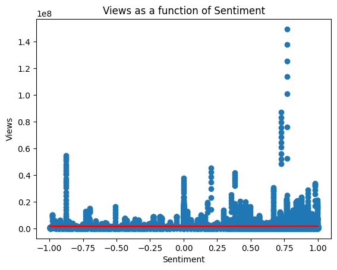

```python
df_lin_reg = df[['sentiment', 'views']]

np_lin_reg = df_lin_reg.values
X = np_lin_reg[:,0]
X_ones = np.vstack([X, np.ones(len(X))]).T
Y = np_lin_reg[:,1]

lst_sq, residual, _, _ = np.linalg.lstsq(X_ones, Y, rcond=None)

slope, intercept = lst_sq
print(lst_sq)

fig, ax = plt.subplots(nrows=1, ncols=1)
ax.scatter(df['sentiment'], df['views'])
ax.plot(X, intercept + slope*X, 'r')
ax.set_title('Views as a function of Sentiment')
ax.set_xlabel('Sentiment')
ax.set_ylabel('Views')
```

**Analysis of Graph:** This plot shows the number of views a video recieves as a function of its sentiment score, along with the corresponding linear regression. Based on the plot, there does not appear to be a correlation between these two variables.

```python
lin_reg = smf.ols(formula="views ~ sentiment ", data=df).fit()
print(lin_reg.summary())
```

```
                            OLS Regression Results
==============================================================================
Dep. Variable:                  views   R-squared:                       0.000
Model:                            OLS   Adj. R-squared:                  0.000
Method:                 Least Squares   F-statistic:                     1.012
Date:                Sat, 18 May 2024   Prob (F-statistic):              0.314
Time:                        17:27:09   Log-Likelihood:            -2.8352e+05
No. Observations:               16985   AIC:                         5.670e+05
Df Residuals:                   16983   BIC:                         5.671e+05
Df Model:                           1
Covariance Type:            nonrobust
==============================================================================
                 coef    std err          t      P>|t|      [0.025      0.975]
------------------------------------------------------------------------------
Intercept   1.628e+06   3.97e+04     41.066      0.000    1.55e+06    1.71e+06
sentiment   6.209e+04   6.17e+04      1.006      0.314   -5.89e+04    1.83e+05
==============================================================================
Omnibus:                    30594.481   Durbin-Watson:                   1.843
Prob(Omnibus):                  0.000   Jarque-Bera (JB):         61009813.709
Skew:                          13.016   Prob(JB):                         0.00
Kurtosis:                     295.455   Cond. No.                         2.19
==============================================================================

Notes:
[1] Standard Errors assume that the covariance matrix of the errors is correctly specified.
```

**Analysis of Regression** Let our null hypothesis H0 be that there is no relation between sentiment and view count. If we look at the 0.05 significance level and perform a p-test, https://www.scribbr.com/statistics/p-value/#:~:text=The%20p%20value%20is%20a,to%20reject%20the%20null%20hypothesis, based on the summary table of our regression, we accept the null hypothesis because our p-value is 0.314 which is greater than our significance level. Thus, there is no relation between sentiment and view count.

What if we look at the relation between sentiment and comment count?

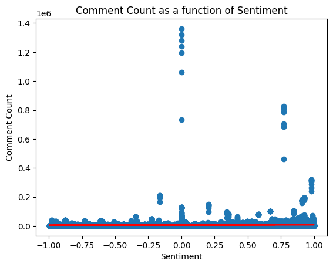

```python
df_lin_reg = df[['sentiment', 'comment_count']]

np_lin_reg = df_lin_reg.values
X = np_lin_reg[:,0]
X_ones = np.vstack([X, np.ones(len(X))]).T
Y = np_lin_reg[:,1]

lst_sq, residual, _, _ = np.linalg.lstsq(X_ones, Y, rcond=None)

slope, intercept = lst_sq

fig, ax = plt.subplots(nrows=1, ncols=1)
ax.scatter(df['sentiment'], df['comment_count'])
ax.plot(X, intercept + slope*X, 'r')
ax.set_title('Comment Count as a function of Sentiment')
ax.set_xlabel('Sentiment')
ax.set_ylabel('Comment Count')
```

**Analysis of Graph:** This plot shows the amount of comments a video recieves as a function of the video sentiment. Based on this plot, there does not appear to be a relation between these variables.

```python
lin_reg = smf.ols(formula="comment_count ~ sentiment ", data=df).fit()
print(lin_reg.summary())
```

```
                            OLS Regression Results
==============================================================================
Dep. Variable:          comment_count   R-squared:                       0.000
Model:                            OLS   Adj. R-squared:                  0.000
Method:                 Least Squares   F-statistic:                     3.917
Date:                Sat, 18 May 2024   Prob (F-statistic):             0.0478
Time:                        17:40:03   Log-Likelihood:            -2.0045e+05
No. Observations:               16985   AIC:                         4.009e+05
Df Residuals:                   16983   BIC:                         4.009e+05
Df Model:                           1
Covariance Type:            nonrobust
==============================================================================
                 coef    std err          t      P>|t|      [0.025      0.975]
------------------------------------------------------------------------------
Intercept   6194.9965    297.955     20.792      0.000    5610.975    6779.018
sentiment    917.5843    463.640      1.979      0.048       8.802    1826.367
==============================================================================
Omnibus:                    42512.628   Durbin-Watson:                   1.990
Prob(Omnibus):                  0.000   Jarque-Bera (JB):        633384197.655
Skew:                          27.548   Prob(JB):                         0.00
Kurtosis:                     947.428   Cond. No.                         2.19
==============================================================================

Notes:
[1] Standard Errors assume that the covariance matrix of the errors is correctly specified.
```

**Analysis of Regression** Let our null hypothesis H0 be that there is no relation between sentiment and comment count. If we look at the 0.05 significance level and perform a p-test, based on the summary table of our regression, we reject the null hypothesis because our p-value is 0.048 which is less than our significance level. Thus, there is a relation between sentiment and comment count. However, this is not a strong correlation as we have an R-squared value of 0.000 which means that 0.0% of the variance in comment count can be explained by our model.

Since it appears there is little correlation between our variables in our dataset, what if we only look at one video category?

**Step 17:** Lets look at only educational videos now.

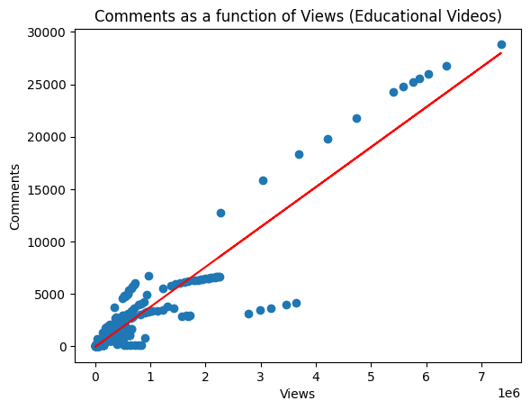

```python
df2 = df[df['category_id'] == 'Education']
df2.head()

df_lin_reg = df2[['views', 'comment_count']]
np_lin_reg = df_lin_reg.values
X = np_lin_reg[:,0]
X_ones = np.vstack([X, np.ones(len(X))]).T
Y = np_lin_reg[:,1]

lst_sq, residual, _, _ = np.linalg.lstsq(X_ones, Y, rcond=None)
slope, intercept = lst_sq

fig, ax = plt.subplots(nrows=1, ncols=1)
ax.scatter(df2['views'], df2['comment_count'])
ax.plot(X, intercept + slope*X, 'r')
ax.set_title('Comments as a function of Views (Educational Videos)')
ax.set_xlabel('Views')
ax.set_ylabel('Comments')
plt.show()
```

**Analysis of Graph:** This graph plots the number of comments an educational video receives as a function of the view count. Based on this plot, there appears to be a strong positive linear relation between the two variables.

```python
lin_reg = smf.ols(formula="comment_count ~ views ", data=df2).fit()
print(lin_reg.summary())

alpha = 0.05
dfn = 1 #k (degrees of freedom)
dfd = 410 #n - k -1

critical_val = f.ppf(1-alpha, dfn, dfd)
print("critical_val: ", critical_val)
```

```
                            OLS Regression Results
==============================================================================
Dep. Variable:          comment_count   R-squared:                       0.867
Model:                            OLS   Adj. R-squared:                  0.867
Method:                 Least Squares   F-statistic:                     2684.
Date:                Sat, 18 May 2024   Prob (F-statistic):          4.95e-182
Time:                        17:43:54   Log-Likelihood:                -3581.5
No. Observations:                 412   AIC:                             7167.
Df Residuals:                     410   BIC:                             7175.
Df Model:                           1
Covariance Type:            nonrobust
==============================================================================
                 coef    std err          t      P>|t|      [0.025      0.975]
------------------------------------------------------------------------------
Intercept    -57.6472     83.240     -0.693      0.489    -221.277     105.982
views          0.0038   7.36e-05     51.806      0.000       0.004       0.004
==============================================================================
Omnibus:                      236.578   Durbin-Watson:                   1.775
Prob(Omnibus):                  0.000   Jarque-Bera (JB):             4127.029
Skew:                          -2.057   Prob(JB):                         0.00
Kurtosis:                      17.950   Cond. No.                     1.32e+06
==============================================================================

Notes:
[1] Standard Errors assume that the covariance matrix of the errors is correctly specified.
[2] The condition number is large, 1.32e+06. This might indicate that there are
strong multicollinearity or other numerical problems.
critical_val:  3.864239267921459
```

**Analysis of Regression:** If we have our null hypothesis H0 be there is no relationship between views and comments for educational videos, then we would reject that hypothesis. The reason we reject this hypothesis is that since alpha = 0.05, based on our dataset we have a critical value of 3.864. From the OLS linear regression data, we have an F statistic of 2684. Since our critical value is less than our F statistic, we reject our null hypothesis. Thus there is a relationship between views and comments for educational videos.

Now that we only look at one video category, is sentiment now a useful statistic?

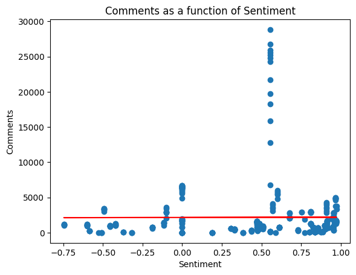

```python
df_lin_reg = df2[['sentiment', 'comment_count']]
np_lin_reg = df_lin_reg.values
X = np_lin_reg[:,0]
X_ones = np.vstack([X, np.ones(len(X))]).T
Y = np_lin_reg[:,1]

lst_sq, residual, _, _ = np.linalg.lstsq(X_ones, Y, rcond=None)
slope, intercept = lst_sq

fig, ax = plt.subplots(nrows=1, ncols=1)
ax.scatter(df2['sentiment'], df2['comment_count'])
ax.plot(X, intercept + slope*X, 'r')
ax.set_title('Comments as a function of Sentiment')
ax.set_xlabel('Sentiment')
ax.set_ylabel('Comments')
plt.show()
```

**Analysis of Graph:** This plot shows the amount of comments an educational video gets as a function of sentiment. Based on this plot, there does not appear to be any correlation between the variables.

```python
lin_reg = smf.ols(formula="comment_count ~ sentiment ", data=df2).fit()
print(lin_reg.summary())

alpha = 0.05
dfn = 1 #k (degrees of freedom)
dfd = 410 #n - k -1

critical_val = f.ppf(1-alpha, dfn, dfd)
print("critical_val: ", critical_val)
```

```
                            OLS Regression Results
==============================================================================
Dep. Variable:          comment_count   R-squared:                       0.000
Model:                            OLS   Adj. R-squared:                 -0.002
Method:                 Least Squares   F-statistic:                  0.008253
Date:                Sat, 18 May 2024   Prob (F-statistic):              0.928
Time:                        17:53:53   Log-Likelihood:                -3997.8
No. Observations:                 412   AIC:                             8000.
Df Residuals:                     410   BIC:                             8008.
Df Model:                           1
Covariance Type:            nonrobust
==============================================================================
                 coef    std err          t      P>|t|      [0.025      0.975]
------------------------------------------------------------------------------
Intercept   2155.8290    273.552      7.881      0.000    1618.090    2693.568
sentiment     36.8155    405.258      0.091      0.928    -759.826     833.457
==============================================================================
Omnibus:                      411.255   Durbin-Watson:                   0.312
Prob(Omnibus):                  0.000   Jarque-Bera (JB):            10526.913
Skew:                           4.549   Prob(JB):                         0.00
Kurtosis:                      26.031   Cond. No.                         2.64
==============================================================================

Notes:
[1] Standard Errors assume that the covariance matrix of the errors is correctly specified.
critical_val:  3.864239267921459
```

**Analysis of Regression:** If we have H0 be there is no relationship between sentiment and comments for educational videos, then we would accept that null hypothesis. The reason we accept this hypothesis is that since alpha = 0.05, based on our dataset we have a critical value of 3.864. From the OLS linear regression data, we have an F statistic of 0.008253. Since our critical value is greater than our F statistic, we accept our null hypothesis. Thus there is no relationship between sentiment and comments for educational videos.

What about the log of like-dislike-ratio?

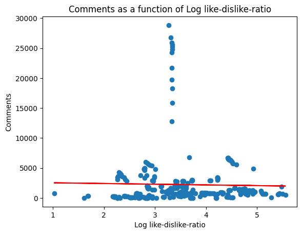

```python
df_lin_reg = df2[['like_dislike_ratio', 'comment_count']]
df_lin_reg = df_lin_reg.dropna()
np_lin_reg = df_lin_reg.values
X = np_lin_reg[:,0]
X_ones = np.vstack([X, np.ones(len(X))]).T
Y = np_lin_reg[:,1]

lst_sq, residual, _, _ = np.linalg.lstsq(X_ones, Y, rcond=None)
slope, intercept = lst_sq

fig, ax = plt.subplots(nrows=1, ncols=1)
ax.scatter(df2['like_dislike_ratio'], df2['comment_count'])
ax.plot(X, intercept + slope*X, 'r')
ax.set_title('Comments as a function of Log like-dislike-ratio')
ax.set_xlabel('Log like-dislike-ratio')
ax.set_ylabel('Comments')
plt.show()
```

**Analysis of Graph:** This plot shows the amount of comments an educational video recieves as a function of the log like-dislike-ratio of the video. Based on this plot, there does not appear to be any correlation between the two variables.

```python
lin_reg = smf.ols(formula="comment_count ~ like_dislike_ratio ", data=df2).fit()
print(lin_reg.summary())

alpha = 0.05
dfn = 1 #k (degrees of freedom)
dfd = 410 #n - k -1

critical_val = f.ppf(1-alpha, dfn, dfd)
print("critical_val: ", critical_val)
```

```
                            OLS Regression Results
==============================================================================
Dep. Variable:          comment_count   R-squared:                       0.001
Model:                            OLS   Adj. R-squared:                 -0.002
Method:                 Least Squares   F-statistic:                    0.2564
Date:                Sat, 18 May 2024   Prob (F-statistic):              0.613
Time:                        18:01:46   Log-Likelihood:                -3913.5
No. Observations:                 403   AIC:                             7831.
Df Residuals:                     401   BIC:                             7839.
Df Model:                           1
Covariance Type:            nonrobust
======================================================================================
                         coef    std err          t      P>|t|      [0.025      0.975]
--------------------------------------------------------------------------------------
Intercept           2646.8174    863.314      3.066      0.002     949.631    4344.004
like_dislike_ratio  -116.9899    231.041     -0.506      0.613    -571.192     337.212
==============================================================================
Omnibus:                      399.178   Durbin-Watson:                   0.306
Prob(Omnibus):                  0.000   Jarque-Bera (JB):             9835.117
Skew:                           4.496   Prob(JB):                         0.00
Kurtosis:                      25.469   Cond. No.                         17.3
==============================================================================

Notes:
[1] Standard Errors assume that the covariance matrix of the errors is correctly specified.
critical_val:  3.864239267921459
```

**Analysis of Regression:** If we have H0 be there is no relationship between log-like-dislike ratio and comments for educational videos, then we would accept that null hypothesis. The reason we accept this hypothesis is that since alpha = 0.05, based on our dataset we have a critical value of 3.864. From the OLS linear regression data, we have an F statistic of 0.2564. Since our critical value is greater than our F statistic, we accept our null hypothesis. Thus there is no relationship between log-like-dislike ratio and comments for educational videos.

Are likes a good predictor of comment count?

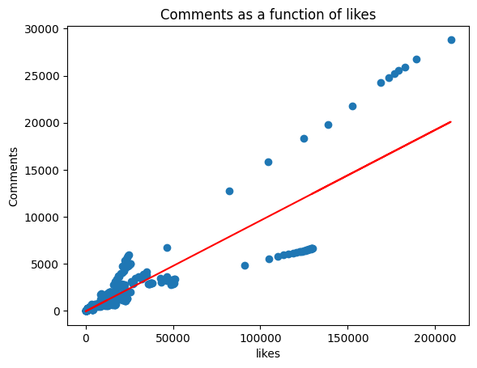

```python
df_lin_reg = df2[['likes', 'comment_count']]
df_lin_reg = df_lin_reg.dropna()
np_lin_reg = df_lin_reg.values
X = np_lin_reg[:,0]
X_ones = np.vstack([X, np.ones(len(X))]).T
Y = np_lin_reg[:,1]

lst_sq, residual, _, _ = np.linalg.lstsq(X_ones, Y, rcond=None)
slope, intercept = lst_sq

fig, ax = plt.subplots(nrows=1, ncols=1)
ax.scatter(df2['likes'], df2['comment_count'])
ax.plot(X, intercept + slope*X, 'r')
ax.set_title('Comments as a function of likes')
ax.set_xlabel('likes')
ax.set_ylabel('Comments')
```

**Analysis of Graph:** This plot shows the amount of comments an educational video recieves as a function of the number of likes the video recieves. Based on this plot, there appears to be a strong positive linear relationship between the two variables.

```python
alpha = 0.05
dfn = 1 #k (degrees of freedom)
dfd = 410 #n - k -1

critical_val = f.ppf(1-alpha, dfn, dfd)
print("critical_val: ", critical_val)
lin_reg = smf.ols(formula="comment_count ~ likes ", data=df2).fit()
print(lin_reg.summary())
```

```
critical_val:  3.864239267921459
                            OLS Regression Results
==============================================================================
Dep. Variable:          comment_count   R-squared:                       0.759
Model:                            OLS   Adj. R-squared:                  0.759
Method:                 Least Squares   F-statistic:                     1293.
Date:                Sat, 18 May 2024   Prob (F-statistic):          7.17e-129
Time:                        18:09:45   Log-Likelihood:                -3704.5
No. Observations:                 412   AIC:                             7413.
Df Residuals:                     410   BIC:                             7421.
Df Model:                           1
Covariance Type:            nonrobust
==============================================================================
                 coef    std err          t      P>|t|      [0.025      0.975]
------------------------------------------------------------------------------
Intercept    -39.9881    114.034     -0.351      0.726    -264.153     184.177
likes          0.0963      0.003     35.964      0.000       0.091       0.102
==============================================================================
Omnibus:                      100.004   Durbin-Watson:                   0.744
Prob(Omnibus):                  0.000   Jarque-Bera (JB):             1042.480
Skew:                           0.691   Prob(JB):                    4.25e-227
Kurtosis:                      10.669   Cond. No.                     5.06e+04
==============================================================================

Notes:
[1] Standard Errors assume that the covariance matrix of the errors is correctly specified.
[2] The condition number is large, 5.06e+04. This might indicate that there are
strong multicollinearity or other numerical problems.
```

What about the upload date of the video?

**Explanation of code:** This code is pretty much the same as the previous one in that it plots the datetime against the comment count and creates a residual line based on the data. The only difference, though, is that we are dealing with datetime. Since we want to perform least squares, we need the values of the datetime to be a number. We do this by creating a new column, "upload_datetime_numeric." For each value in the upload_datetime column, a timestamp object with the date 01/01/1970 is created and subtracted from that datetime value. The point of this is to subtract the Unix epoch, which is the standard UTC time. This creates a timedelta object with the value being the amount of time away from 01/01/1970. Then, we perform integer division with 1s to convert the timedelta value into seconds so that it can be more easily used in the least squares computation.

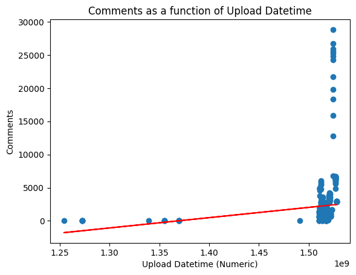

```python
# Convert datetime to numeric format (e.g., seconds since epoch)
df2['upload_datetime_numeric'] = (df2['upload_datetime'] - pd.Timestamp("1970-01-01")) // pd.Timedelta('1s')
# Prepare data for linear regression
df_lin_reg = df2[['upload_datetime_numeric', 'comment_count']].dropna()
np_lin_reg = df_lin_reg.values
X = np_lin_reg[:, 0]
Y = np_lin_reg[:, 1]

# Add a column of ones to X for the intercept term
X_ones = np.vstack([X, np.ones(len(X))]).T

# Perform the least squares fitting
lst_sq, residual, _, _ = np.linalg.lstsq(X_ones, Y, rcond=None)
slope, intercept = lst_sq

# Plotting the data and the regression line
fig, ax = plt.subplots(nrows=1, ncols=1)
ax.scatter(df2['upload_datetime_numeric'], df2['comment_count'])
ax.plot(df2['upload_datetime_numeric'], intercept + slope * df2['upload_datetime_numeric'], 'r')
ax.set_title('Comments as a function of Upload Datetime')
ax.set_xlabel('Upload Datetime (Numeric)')
ax.set_ylabel('Comments')
plt.show()
```

**Analysis of Plot** This plot shows the amount of comments an educational video recieves based on the upload date. Based on this plot, there appears to be a positive linear relation between the two variables, but it is hard to see the strength of it based on the lack of spread of the data.

```python
# Perform linear regression using statsmodels
lin_reg = smf.ols(formula="comment_count ~ upload_datetime_numeric", data=df2).fit()
print(lin_reg.summary())


critical_val = f.ppf(1-alpha, dfn, dfd)
print("critical_val: ", critical_val)
lin_reg = smf.ols(formula="comment_count ~ likes ", data=df2).fit()
print(lin_reg.summary())
```

```
                            OLS Regression Results
==============================================================================
Dep. Variable:          comment_count   R-squared:                       0.024
Model:                            OLS   Adj. R-squared:                  0.022
Method:                 Least Squares   F-statistic:                     10.25
Date:                Sat, 18 May 2024   Prob (F-statistic):            0.00148
Time:                        18:11:03   Log-Likelihood:                -3992.8
No. Observations:                 412   AIC:                             7990.
Df Residuals:                     410   BIC:                             7998.
Df Model:                           1
Covariance Type:            nonrobust
===========================================================================================
                              coef    std err          t      P>|t|      [0.025      0.975]
-------------------------------------------------------------------------------------------
Intercept               -2.122e+04   7311.276     -2.903      0.004   -3.56e+04   -6850.160
upload_datetime_numeric   1.55e-05   4.84e-06      3.201      0.001    5.98e-06     2.5e-05
==============================================================================
Omnibus:                      412.226   Durbin-Watson:                   0.332
Prob(Omnibus):                  0.000   Jarque-Bera (JB):            10691.008
Skew:                           4.560   Prob(JB):                         0.00
Kurtosis:                      26.229   Cond. No.                     5.71e+10
==============================================================================

Notes:
[1] Standard Errors assume that the covariance matrix of the errors is correctly specified.
[2] The condition number is large, 5.71e+10. This might indicate that there are
strong multicollinearity or other numerical problems.
critical_val:  3.864239267921459
                            OLS Regression Results
==============================================================================
Dep. Variable:          comment_count   R-squared:                       0.759
Model:                            OLS   Adj. R-squared:                  0.759
Method:                 Least Squares   F-statistic:                     1293.
Date:                Sat, 18 May 2024   Prob (F-statistic):          7.17e-129
Time:                        18:11:03   Log-Likelihood:                -3704.5
No. Observations:                 412   AIC:                             7413.
Df Residuals:                     410   BIC:                             7421.
Df Model:                           1
Covariance Type:            nonrobust
==============================================================================
                 coef    std err          t      P>|t|      [0.025      0.975]
------------------------------------------------------------------------------
Intercept    -39.9881    114.034     -0.351      0.726    -264.153     184.177
likes          0.0963      0.003     35.964      0.000       0.091       0.102
==============================================================================
Omnibus:                      100.004   Durbin-Watson:                   0.744
Prob(Omnibus):                  0.000   Jarque-Bera (JB):             1042.480
Skew:                           0.691   Prob(JB):                    4.25e-227
Kurtosis:                      10.669   Cond. No.                     5.06e+04
==============================================================================

Notes:
[1] Standard Errors assume that the covariance matrix of the errors is correctly specified.
[2] The condition number is large, 5.06e+04. This might indicate that there are
strong multicollinearity or other numerical problems.
```

## Machine Learning

**Step 18:** This part of the code focuses on machine learning. It uses gradient descent with ridge regression to predict the comment count based on views. Gradient descent is an algorithm that minimizes loss by iteratively adjusting its parameters. It computes the gradient based off of the initial parameters and then updates the parameters in the opposite direction of the gradient to minimze loss. Then, it repeats this process with the new parameters. It does this for a specified number of times, called epochs. In this case, the gradient descent algorithm also uses ridge regression. Ridge regression is a technique used to improve the stability of the linear regression model by preventing overfitting. Overfitting occurs when a model trains the data too well, leading to noise and other details that are not important being captured.

This code first creates a copy of the second dataframe. The second dataframe is a list of all rows where the column "column_id" is "Education" since that is the category we want to focus on. So, out of the 412 rows that have education as their category, we are choosing to remove 80 of them. In Machine Learning, you do not take the whole dateset to train. Instead, you take around 80% of the dataset to train and keep the rest to the side. So, we randomly choose 80 indices to remove from the list and keep the rest as a part of our training model.

Now that we have our training model, we can start the machine learning process. We choose our views column as the independent variable and our comment_count column as the dependent variable. On the independent variable, we make it homogenous by adding a column of ones to the end. This column will be used for analyzing the bias. Then, we perform gradient descent with ridge regression on the x and y variables. We run the gradient descent with ridge regression algorithm for a specific number of epochs. In this case, that number is 10000000. We do this with a learning rate of 0.00000000000000001 and lambda being 0.000000000001. The learning rate determines how quickly or slowly an algorithm adjusts the parameters during the training process. Lambda is the regularization parameter. It helps prevent overfitting by penalizing large coefficients in the regression model.

There is a lot of trial and error that goes into finding the proper paremeters for the gradient descent. We had to play around with the epochs, learning rate, and lambda to ensure that our loss is continually decreasing as the number of epochs increases.

The result of the gradient descent with ridge regression on this specific data with views as the independent variable and comment_count as the dependent variable is a linear regression model that contains the theta and loss. Theta is the weights, or parameters, of the linear regression model with ridge regression. Each value in theta corresponds to the independent variables. In this case, there is only one independent variable, but there is also the bias to look at. So, the first value in theta is for the views and the second value is for the bias, which is the intercept of the linear regression model. It indicates the expected value of the target variable (comment_count in this case) when all the features (in this case, views) are zero. The loss shows us how far away we are from the actual target values. The bigger the loss, the further away we are. The whole point of seeing the loss is that as the model runs through more and more iterations, it should learn from the last iteration and the loss should decrease. In this case, the loss does do that, as shown by the fact that the first loss is 1.58974459e+09 and the final loss is 1.88238589e+08.

```python
df3 = df2.copy()
df3.reset_index(inplace=True)
df3.drop('index', axis=1, inplace=True)

idx = np.random.choice(df3.shape[0], 80, replace=False)

index_array = df3.index.to_numpy()

for i in idx:

	mask = index_array != i
	index_array = index_array[mask]

train = df3.loc[index_array]

x = np.array(train[['views']])
y = np.array(train['comment_count'])

ones_column = np.ones((x.shape[0], 1))
x = np.concatenate((x, ones_column), axis=1)

# gradient descent with ridge regression
def grad_descent(X,y,T,alpha, lambda_reg):
    m, n = X.shape
    theta = np.zeros(n)
    f = np.zeros(T)
    for i in range(T):
        f[i] = 0.5 * np.linalg.norm(X.dot(theta) - y)**2 + 0.5 * lambda_reg * np.linalg.norm(theta)**2
        g = np.transpose(X).dot(X.dot(theta) - y)
        theta = theta* (1 - (alpha*lambda_reg)/m) - alpha * g
    return(theta,f)

T = 10000000
alpha = 0.00000000000000001
lambda_reg = 0.000000000001

theta, loss = grad_descent(x, y, T, alpha, lambda_reg)

print("Views Theta: ", theta[0])
print("Bias: ", theta[1])
print("All losses: \n", loss/(x.shape[1]))
print("Final Loss: ", loss[-1]/x.shape[1])
```

```
Views Theta:  0.003746901931614275
Bias:  -6.358910061582171e-07
All losses:
 [1.58974459e+09 1.57857423e+09 1.56749289e+09 ... 1.88238589e+08
 1.88238589e+08 1.88238589e+08]
Final Loss:  188238589.0073183
```

**Step 19:** Now that we have a list of all of the losses, we want to plot them over the epochs to ensure that the loss is decreasing as the epochs increase. As mentioned above, the point of tracking the loss is to ensure that the model is learning from itself and the accuracy is increasing over time. So, we plot the loss over all epochs, the first 100 epochs, next 900 epochs, and then the last 9999000 epochs. We create four subplots to have the graphs side by side so we can analyze them.

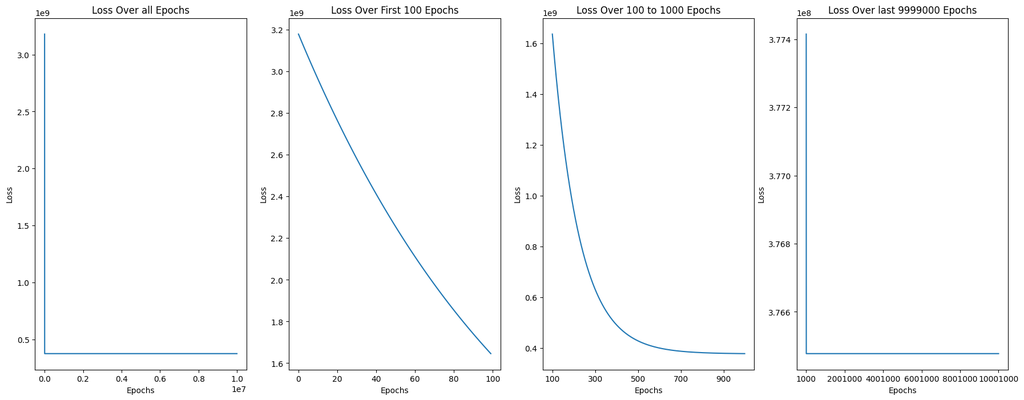

```python
_, ax = plt.subplots(1, 4, figsize=(22, 8))

ax[0].plot(loss)
ax[0].set_xlabel("Epochs")
ax[0].set_ylabel("Loss")
ax[0].set_title("Loss Over all Epochs")

ax[1].plot(loss[:100])
ax[1].set_xlabel("Epochs")
ax[1].set_ylabel("Loss")
ax[1].set_title("Loss Over First 100 Epochs")

ax[2].plot(loss[100:1000])
ax[2].set_xlabel("Epochs")
ax[2].set_ylabel("Loss")
ax[2].set_title("Loss Over 100 to 1000 Epochs")
new_labels = [str(int(tick) + 100) for tick in ax[2].get_xticks()]
ax[2].set_xticklabels(new_labels)

ax[3].plot(loss[1000:])
ax[3].set_xlabel("Epochs")
ax[3].set_ylabel("Loss")
ax[3].set_title("Loss Over last 9999000 Epochs")
new_labels = [str(int(tick) + 1000) for tick in ax[3].get_xticks()]
ax[3].set_xticklabels(new_labels)

plt.show()
```

**Analysis of Graph:** After plotting the graphs, we can see that in all of them, the loss is decreasing as the number of epochs increase, meaning that the model is indeed learning from itself, improving, and getting closer to the true target value.

**Step 20:** Now, we want to do the same thing as before with gradient descent and ridge regression, except this time we want to do it with multiple independent variables. This is called multivariate linear regression. We take multiple independent variables and one dependent variable and run gradient descent with ridge regression on it. Based on the analysis from earlier, we found out that the variables that have a relationship with comment count are the views, likes, and upload date of the video. So, the purpose of using all three variables is to try to more accurately predict the comment count by using three independent variables that affect the dependent variable. After running gradient descent with ridge regression, we again get a theta and a loss. This time, theta has four values, one being the weight of each of the independent variables, and again, the bias. The first value in theta corresponds with views, the second with likes, and the third with the upload datetime. Also, as shown below, the loss is again decreasing over time, meaning the model is learning from itself and improving. This way of running gradient descent with ridge regression portrays the math behind how the algorithm works, but in reality, most of the time this algorithm will be used through pytorch to create a working model that will correctly predict the comment count (this is what we will do next).

```python
df3 = df2.copy()
df3.reset_index(inplace=True)
df3.drop('index', axis=1, inplace=True)

idx = np.random.choice(df3.shape[0], 80, replace=False)

index_array = df3.index.to_numpy()

for i in idx:

	mask = index_array != i
	index_array = index_array[mask]

train = df3.loc[index_array]

x = np.array(train[['views', 'likes', 'upload_datetime_numeric']])
y = np.array(train['comment_count'])

ones_column = np.ones((x.shape[0], 1))
x = np.concatenate((x, ones_column), axis=1)

# gradient descent with ridge regression
def grad_descent(X,y,T,alpha, lambda_reg):
    m, n = X.shape
    theta = np.zeros(n)
    f = np.zeros(T)
    for i in range(T):
        f[i] = 0.5 * np.linalg.norm(X.dot(theta) - y)**2 + 0.5 * lambda_reg * np.linalg.norm(theta)**2
        g = np.transpose(X).dot(X.dot(theta) - y)
        theta = theta* (1 - (alpha*lambda_reg)/m) - alpha * g
    return(theta,f)

T = 100000000
alpha = 0.0000000000000000000000001
lambda_reg = 0.00000000001

theta, loss = grad_descent(x, y, T, alpha, lambda_reg)

print("Views Theta: ", theta[0])
print("Likes Theta:", theta[1])
print("Upload Datetime Theta: ", theta[2])
print("Bias: ", theta[3])
print("All Losses: \n", loss/(x.shape[1]))
print("Final Loss: ", loss[-1]/x.shape[1])
```

```
Views Theta:  1.0148947229243491e-05
Likes Theta: 3.518403713230005e-07
Upload Datetime Theta:  1.373928926290617e-06
Bias:  -4.189333775545096e-14
All Losses:
 [7.32693922e+08 7.32666704e+08 7.32639489e+08 ... 5.50415417e+08
 5.50415417e+08 5.50415417e+08]
Final Loss:  550415416.7213976
```

**Step 21:** Before we get to the pytorch, though, we again want to graph the loss values for each epoch.

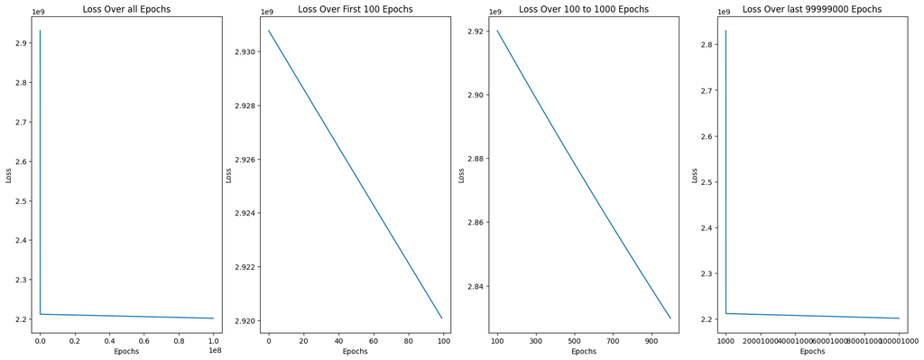

```python
_, ax = plt.subplots(1, 4, figsize=(22, 8))

ax[0].plot(loss)
ax[0].set_xlabel("Epochs")
ax[0].set_ylabel("Loss")
ax[0].set_title("Loss Over all Epochs")

ax[1].plot(loss[:100])
ax[1].set_xlabel("Epochs")
ax[1].set_ylabel("Loss")
ax[1].set_title("Loss Over First 100 Epochs")

ax[2].plot(loss[100:1000])
ax[2].set_xlabel("Epochs")
ax[2].set_ylabel("Loss")
ax[2].set_title("Loss Over 100 to 1000 Epochs")
new_labels = [str(int(tick) + 100) for tick in ax[2].get_xticks()]
ax[2].set_xticklabels(new_labels)

ax[3].plot(loss[1000:])
ax[3].set_xlabel("Epochs")
ax[3].set_ylabel("Loss")
ax[3].set_title("Loss Over last 99999000 Epochs")
new_labels = [str(int(tick) + 1000) for tick in ax[3].get_xticks()]
ax[3].set_xticklabels(new_labels)

plt.show()
```

**Analysis of Graphs:** As before, the loss is decreasing as the number of epochs increases, so this model is also learning from itself and improving with each iteration.

**Step 22:** In actual scenarios, it is much more likely to use a framework like Pytorch to create a neural network in order to conduct machine learning since a lot of the common machine learning techniques are already implemented, you just need to fit it to your dataset. We will give a walk through of how to use pytorch. Additional information can be found here: https://pytorch.org/tutorials/beginner/basics/intro.html.

```python
#imports all necessary pytorch libraries to perform machine learning
import torch
import torch.nn as nn
import torch.optim as optim
import torch.nn.functional as F
from torch.utils.data import DataLoader, TensorDataset
```

Before we can create a neural network, we must first prepare our data. The first step in this process is to split our data into two sets: a training set and a testing set (code to create test set in later section). The training set is what we use for our model to learn and the test set is what we use to evaluate our model. We then split these respective sets into X and Y sets, to represent independent and dependent variables and convert to a pytorch tensor object, a type of multi-dimensional array optimized for pytorch. We then create a pytorch dataset object which allows us to create a pytorch dataloader, an object that efficiently loads and preprocesses data in batches, providing an iterator over the dataset.

```python
df3 = df2.copy()
df3.reset_index(inplace=True)
df3.drop('index', axis=1, inplace=True)

# splitting data / creating test shape
idx = np.random.choice(df3.shape[0], 80, replace=False)
index_array = df3.index.to_numpy()
for i in idx:

	mask = index_array != i
	index_array = index_array[mask]

train = df3.loc[index_array]

x = np.array(train[['views', 'likes', 'upload_datetime_numeric']])
y = np.array(train['comment_count']).reshape(-1,1)

x = torch.tensor(x, dtype=torch.float32)
y = torch.tensor(y, dtype=torch.float32)

dataset = TensorDataset(x, y)
train_loader = DataLoader(dataset, batch_size=2, shuffle=True)
```

We then define our neural network. In this case we define a very simple neural network which only has two linear layers, layers that perform linear transformations on the data. However, we must have an activation function in between these layers in order to have truly seperate network layers. In this case we use ReLU: read more here https://builtin.com/machine-learning/relu-activation-function. It is important to note that the output size of one network layer must be equal to the input size of the next layer.

```python
class SimpleNN(nn.Module):
    def __init__(self):
        super(SimpleNN, self).__init__()
        self.fc1 = nn.Linear(3, 20)
        self.fc2 = nn.Linear(20, 1)

    def forward(self, x):
        x = F.relu(self.fc1(x))
        x = self.fc2(x)
        return x
```

We then define our training loop which is where our model does the actual learning. Before that though, we must define our loss function which measures the difference between the predicted output and the actual target values. We use this loss in order to accurately train our model. We chose to use Mean Squared Error Loss which is a common loss function for regression; read more here: https://www.simplilearn.com/tutorials/statistics-tutorial/mean-squared-error#:~:text=The%20Mean%20Squared%20Error%20measures,it%20relates%20to%20a%20function. We also must define our optimizer, which is what updates the weights for our model. We choose to use Adam which you can read more about here: https://www.geeksforgeeks.org/adam-optimizer/.

To actually train our model, we must use our data loader which we defined in the previous block to load the current batch of data to be processed. We then make a prediction, evaluate our predictions, and use our optimizer function to update our weights.

```python
model = SimpleNN()
criterion = nn.MSELoss()
optimizer = optim.Adam(model.parameters(), lr=0.000001)
num_epochs = 25001

total_loss = []

for epoch in range(num_epochs):
    for inputs, labels in train_loader:

        # Forward pass
        outputs = model(inputs) # make predictions
        loss = criterion(outputs, labels) # evaluate predictions

        # Backward pass and optimization
        optimizer.zero_grad()
        loss.backward()
        optimizer.step()

    total_loss.append(loss.item())

    if(epoch%500 == 0):
        print(f'Epoch [{epoch+1}/{num_epochs}], Loss: {loss.item():.4f}')
```

```
Epoch [1/25001], Loss: 437966908424192.0000
Epoch [501/25001], Loss: 5297259.5000
Epoch [1001/25001], Loss: 56031.5508
Epoch [1501/25001], Loss: 11776493.0000
Epoch [2001/25001], Loss: 535741.8125
Epoch [2501/25001], Loss: 3053875.5000
Epoch [3001/25001], Loss: 27740.7812
Epoch [3501/25001], Loss: 3084143.0000
Epoch [4001/25001], Loss: 6726786.0000
Epoch [4501/25001], Loss: 6630443.0000
Epoch [5001/25001], Loss: 3246335.7500
Epoch [5501/25001], Loss: 1746570.5000
Epoch [6001/25001], Loss: 435695.4062
Epoch [6501/25001], Loss: 101827.6328
Epoch [7001/25001], Loss: 1336429.2500
Epoch [7501/25001], Loss: 3249747.0000
Epoch [8001/25001], Loss: 18704.6406
Epoch [8501/25001], Loss: 403959.9688
Epoch [9001/25001], Loss: 1301065.2500
Epoch [9501/25001], Loss: 11912056.0000
Epoch [10001/25001], Loss: 705619.7500
Epoch [10501/25001], Loss: 7950005.5000
Epoch [11001/25001], Loss: 442223.0000
Epoch [11501/25001], Loss: 146397.0156
Epoch [12001/25001], Loss: 5236489.0000
Epoch [12501/25001], Loss: 1651492.2500
Epoch [13001/25001], Loss: 45259.1680
Epoch [13501/25001], Loss: 12094461.0000
Epoch [14001/25001], Loss: 208918.6875
Epoch [14501/25001], Loss: 5941717.0000
Epoch [15001/25001], Loss: 144957.4375
Epoch [15501/25001], Loss: 6220939.5000
Epoch [16001/25001], Loss: 8812799.0000
Epoch [16501/25001], Loss: 8724644.0000
Epoch [17001/25001], Loss: 1406572.3750
Epoch [17501/25001], Loss: 1776624.0000
Epoch [18001/25001], Loss: 4177502.2500
Epoch [18501/25001], Loss: 620847.8125
Epoch [19001/25001], Loss: 160905.8438
Epoch [19501/25001], Loss: 1351879.2500
Epoch [20001/25001], Loss: 18142.2773
Epoch [20501/25001], Loss: 691683.5625
Epoch [21001/25001], Loss: 1900015.6250
Epoch [21501/25001], Loss: 1470460.5000
Epoch [22001/25001], Loss: 1827660.7500
Epoch [22501/25001], Loss: 1250210.7500
Epoch [23001/25001], Loss: 229938.7969
Epoch [23501/25001], Loss: 1480417.5000
Epoch [24001/25001], Loss: 1122601.3750
Epoch [24501/25001], Loss: 785888.0000
Epoch [25001/25001], Loss: 1702925.6250
```

```
25001
```

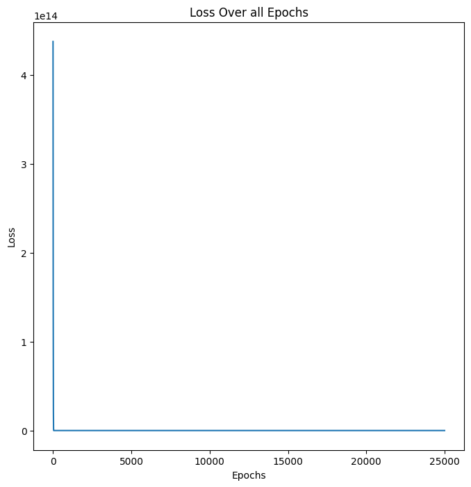

```python
_, ax = plt.subplots(1, 1, figsize=(8, 8))

print(len(total_loss))
ax.plot(total_loss)
ax.set_xlabel("Epochs")
ax.set_ylabel("Loss")
ax.set_title("Loss Over all Epochs")

plt.show()
```

Here is where we evaluate our model. This is very similar to training except now we must set our neural network to evaluate, not learn.

```python
test = df3.iloc[idx]
x = np.array(test[['views', 'likes', 'upload_datetime_numeric']])
y = np.array(test['comment_count']).reshape(-1,1)

x = torch.tensor(x, dtype=torch.float32)
y = torch.tensor(y, dtype=torch.float32)

dataset = TensorDataset(x, y)
test_loader = DataLoader(dataset, batch_size=2, shuffle=True)

model.eval()
with torch.no_grad():
    predictions = model(x)
    mse = criterion(predictions, y).item()
    print(f'Mean Squared Error on test set: {mse:.4f}')

    # Calculate R-squared
    ss_total = torch.sum((y - torch.mean(y)) ** 2).item()  # Total sum of squares
    ss_residual = torch.sum((y - predictions) ** 2).item() # Residual sum of squares
    r2_score = 1 - (ss_residual / ss_total)
    print(f'R-squared on test set: {r2_score:.4f}')
```

```
Mean Squared Error on test set: 3273487.2500
R-squared on test set: 0.8338
```

**Analysis of Model:** Based on the evaluation of our model from our test set, we can see that we have a very high R-squared value, at 0.8338, which shows that our model does a very good job at predicting our data. This can even be improved by testing out different model parameters like number of epochs and learning rate.

## Interpretation

Through our analysis of the YouTube Trending Dataset, we have concluded that the most important variables to predict the comment count for a video are views, likes and upload date. From this, we can create a very accurate model to predict video comments. From this, YouTube content creators can understand what are the important things to focus on improving in order to help generate revenue. We have also realized that it is important for content creators to focus on their specific category, since it appears to be a different model across categories to predict comments.

Now that we have interpreted our results, we have completed a walkthrough of the entire data science lifecycle.